# Analysis of enhancer context

Melanie (1028-02098-001-001)

February 24, 2026

# Introduction

The goal of this analysis is to investigate the contrast between in silico and in vivo context of a motif. This will involve understanding the independence of a pioneering even, as well as assessing the impacts of CpGs across enhancers as another facet of context.

# Computational Setup

```r
#Standard packages
library(rtracklayer) ; library(GenomicRanges); library(magrittr) ; library(Biostrings)
library(ggplot2) ; library(reshape2); library(plyranges); library(Rsamtools); library(parallel)
library(dplyr); library(data.table); library(patchwork); library(readr); library(testit)

#KNITR Options
setwd("/n/projects/mw2098/publications/2024_weilert_acc/code/2_analysis/")
figure_filepath<-"figures/15_enhancer_context"
options(knitr.figure_dir=figure_filepath, java.parameters = "- Xmx6g")

#Lab sources
source("scripts/r/granges_common.r")
source("scripts/r/metapeak_common.r")
source("scripts/r/knitr_common.r")
source("scripts/r/caching.r")
source("scripts/r/metapeak_functions.r")

#Specific sources
library(BSgenome.Mmusculus.UCSC.mm10)
library(TxDb.Mmusculus.UCSC.mm10.knownGene)
library(ggseqlogo)
source("scripts/r/motif_functions.r")
library(spectral)

#Pre-existing variables
threads <- 5
bsgenome<-BSgenome.Mmusculus.UCSC.mm10
txdb<-TxDb.Mmusculus.UCSC.mm10.knownGene

#model information
tasks<-c('oct4', 'sox2', 'nanog', 'klf4', 'zic3')
motif_to_task.list<-list('Oct4-Sox2' = 'oct4', 'Sox2' = 'sox2', 'Klf4' = 'klf4', 'Zic3' = 'zic3', 'Nanog' = 'nanog')
motif_to_task.df<-data.frame(task = motif_to_task.list %>% unlist, motif = names(motif_to_task.list))
output_length <- 1000
input_length <- 2032
count_threshold<-20

#experimental data information
motifs.path<-'tsv/mapped_motifs/all_instances_curated_0based_w_perturb.tsv.gz' #'tsv/mapped_motifs/all_instances_curated_1based.tsv.gz'
regions.path<-'tsv/mapped_motifs/all_islands_curated_1based_w_experimental_data.tsv.gz'
seqlet_ids.path<-'tsv/mapped_motifs/all_pattern_ids.tsv'

marg.path<-'tsv/insilico/marginalizations/motifs/all_marginalizations.tsv.gz'
atac_dinuc_marg.path<-'tsv/insilico/marginalizations/dinucleotides/marginalizations_atac_wt.tsv.gz'
bind_dinuc_marg.path<-'tsv/insilico/marginalizations/dinucleotides/marginalizations_bpnet_osknz.tsv.gz'
paired_perturbs.path<-'tsv/genomic/all_pairs_curated_0based_w_perturb.tsv.gz'

motifs_w_alternate_perturbs.path<-'tsv/mapped_motifs/all_instances_curated_0based_w_alternate_perturb.tsv.gz'

enhancer_motifs.path<-'tsv/genomic/enhancers/enhancer_motifs.tsv.gz'
atac_contrib.path<-'shap/atac_wt_fold1_atac_counts.bw'

nexus.bw.list<-list(zic3 = list(pos = 'bw/mesc_zic3_nexus_combined_positive.bw',
                                neg = 'bw/mesc_zic3_nexus_combined_negative.bw'),
                    oct4 = list(pos = 'bw/mesc_oct4_nexus_combined_positive.bw',
                                neg = 'bw/mesc_oct4_nexus_combined_negative.bw'),
                    sox2 = list(pos = 'bw/mesc_sox2_nexus_combined_positive.bw',
                                neg = 'bw/mesc_sox2_nexus_combined_negative.bw'),
                    klf4 = list(pos = 'bw/mesc_klf4_nexus_combined_positive.bw',
                                neg = 'bw/mesc_klf4_nexus_combined_negative.bw'),
                    nanog = list(pos = 'bw/mesc_nanog_nexus_combined_positive.bw',
                                 neg = 'bw/mesc_nanog_nexus_combined_negative.bw'))

models.list<-list(bpnet_osknz = c('oct4','sox2','nanog','klf4','zic3'),
                  atac_wt = c('atac'),
                  atac_0h = c('atac'),
                  atac_3h = c('atac'),
                  atac_6h = c('atac'),
                  atac_9h = c('atac'),
                  atac_12h = c('atac'),
                  atac_15h = c('atac'))
```

In this analysis we left off the Oct-only motif because its mostly ERV-derived and distance-dependence soft syntax doesn’t make sense in that context. Won’t add to the analysis nor refute it.

# Import motifs and their associated data

Read in motifs with perturbation scores. Calculate distance from different values as a baseline to explore context scores.

```r
atac_peaks.gr<-rtracklayer::import('narrowpeak/mesc_atac_peaks.narrowPeak') %>% GenomicRanges::resize(., 1, 'center')

motifs.df<-readr::read_tsv(motifs.path)
motifs.gr<-motifs.df %>%
  makeGRangesFromDataFrame(keep.extra.columns = T, starts.in.df.are.0based = F,
                           seqnames.field = 'seqnames', start.field = 'start', end.field = 'end', strand.field = 'strand') %>%
  plyranges::mutate(atac_max = regionWhichMaxs(GenomicRanges::resize(., 1000, 'center'), 'bw/mesc_native_atac_combined_normalized.bw'),
                    distance_from_atac_max = abs(((start - end)/2 + start) - atac_max),
                    distance_from_peak_summit = GenomicRanges::distanceToNearest(., atac_peaks.gr, ignore.strand = T))

motifs.df<-motifs.gr %>% as.data.frame()
regions.df<-readr::read_tsv(regions.path)
```

Read in all mapped motifs without curation.

```r
seqlet_ids.df<-readr::read_tsv(seqlet_ids.path) %>% dplyr::filter(fold == 'fold1')
```

# Compare marginalization and perturbation scores

Collect marginalization and perturbation scores side by side.

```r
marg.df<-readr::read_tsv(marg.path) %>% as.data.frame
motifs.df<-motifs.df %>% dplyr::left_join(marg.df) %>% as.data.frame

motifs.df<-lapply(names(motif_to_task.list), function(x){
  motif.df<-motifs.df %>% dplyr::filter(motif==x)
  motif.df$bind_marg<-motif.df[[paste0(motif_to_task.list[[x]], '_marg')]]
  motif.df$acc_marg<-motif.df[['atac_wt_marg']]

  motif.df$bind_perturb<-log(motif.df[[paste0('bpnet_osknz.', motif_to_task.list[[x]], '.WT.pred_sum')]]) -
    log(motif.df[[paste0('bpnet_osknz.', motif_to_task.list[[x]], '.dA.pred_sum')]])
  motif.df$acc_perturb<-log(motif.df$`atac_wt.atac.WT.pred_sum`) - log(motif.df$`atac_wt.atac.dA.pred_sum`)

  return(motif.df)
}) %>% rbindlist()

readr::write_tsv(motifs.df, 'tsv/mapped_motifs/all_instances_curated_1based_with_scores.tsv.gz')
```

## Showcase Akr1cl enhancer

```r
curated_region_id<-3491
curated_coords<-c(65037600, 65037950)
curated_enhancer_boundaries.gr<-GRanges('chr1', IRanges(curated_coords[1], curated_coords[2]))
```

Generate contribution scores of mapped motifs.

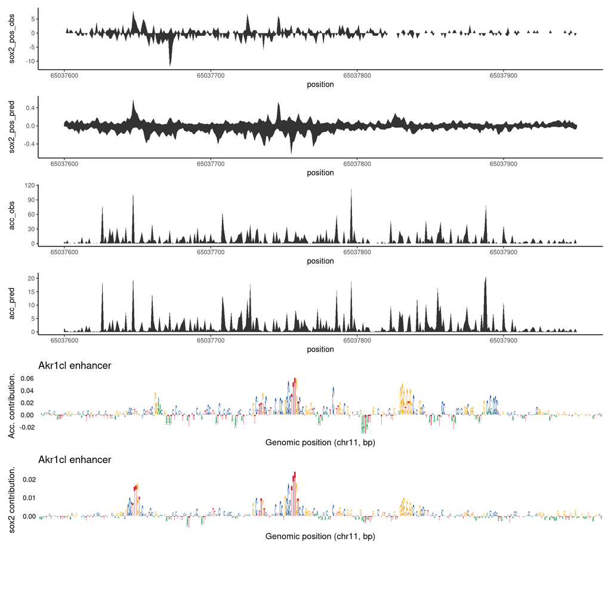

```r
curated_enhancer.df<-data.frame(
  acc_contrib = standard_metapeak_matrix(regions.gr = curated_enhancer_boundaries.gr, sample.cov = 'shap/atac_wt_fold1_atac_counts.bw',
                                         keep_region_coordinates = T) %>% t(),
  sox2_contrib = standard_metapeak_matrix(regions.gr = curated_enhancer_boundaries.gr, sample.cov = 'shap/bpnet_osknz_fold1_sox2_counts.bw',
                                         keep_region_coordinates = T) %>% t(),
  sox2_pos_obs = standard_metapeak_matrix(regions.gr = curated_enhancer_boundaries.gr, sample.cov = 'bw/mesc_sox2_nexus_combined_positive.bw',
                                         keep_region_coordinates = T) %>% t(),
  sox2_neg_obs = standard_metapeak_matrix(regions.gr = curated_enhancer_boundaries.gr, sample.cov = 'bw/mesc_sox2_nexus_combined_negative.bw',
                                         keep_region_coordinates = T) %>% t(),
  sox2_pos_pred = standard_metapeak_matrix(regions.gr = curated_enhancer_boundaries.gr, sample.cov = 'preds/bpnet_osknz_fold1_sox2_pos_peaks_all.bw',
                                         keep_region_coordinates = T) %>% t(),
  sox2_neg_pred = standard_metapeak_matrix(regions.gr = curated_enhancer_boundaries.gr, sample.cov = 'preds/bpnet_osknz_fold1_sox2_neg_peaks_all.bw',
                                         keep_region_coordinates = T) %>% t(),
  acc_obs = standard_metapeak_matrix(regions.gr = curated_enhancer_boundaries.gr, sample.cov = 'bw/mesc_native_atac_cutsites_combined.bw',
                                         keep_region_coordinates = T) %>% t(),
  acc_pred = standard_metapeak_matrix(regions.gr = curated_enhancer_boundaries.gr, sample.cov = 'preds/atac_wt_fold1_combined_atac_atac_peaks_all.bw',
                                         keep_region_coordinates = T) %>% t(),

  seq = getSeq(bsgenome, curated_enhancer_boundaries.gr, as.character = T) %>% stringr::str_split_1(pattern = ''),
  position = start(curated_enhancer_boundaries.gr):end(curated_enhancer_boundaries.gr)
)

# Generate sequence logo
acc_contrib.plot<-curated_enhancer.df%>%
  tidyr::pivot_wider(names_from = seq, values_from = acc_contrib) %>%
  dplyr::select(A, C, G, T) %>% as.matrix() %>% t() %>%
ggseqlogo(., method='custom', seq_type='dna') +
  scale_y_continuous(name = 'Acc. contribution.')+
  scale_x_discrete(name = 'Genomic position (chr11, bp)')+
  ggtitle('Akr1cl enhancer')
sox2_contrib.plot<-curated_enhancer.df %>%
  tidyr::pivot_wider(names_from = seq, values_from = sox2_contrib) %>%
  dplyr::select(A, C, G, T) %>% as.matrix() %>% t() %>%
ggseqlogo(., method='custom', seq_type='dna') +
  scale_y_continuous(name = 'sox2 contribution.')+
  scale_x_discrete(name = 'Genomic position (chr11, bp)')+
  ggtitle('Akr1cl enhancer')
sox2_bind.plot<-curated_enhancer.df %>%
  ggplot(.)+
  geom_area(aes(x = position, y = sox2_pos_obs))+
  geom_area(aes(x = position, y = sox2_neg_obs * -1))+
  theme_classic()
sox2_pred.plot<-curated_enhancer.df %>%
  ggplot(.)+
  geom_area(aes(x = position, y = sox2_pos_pred))+
  geom_area(aes(x = position, y = sox2_neg_pred * -1))+
  theme_classic()
atac_obs.plot<-curated_enhancer.df %>%
  ggplot(.)+
  geom_area(aes(x = position, y = acc_obs))+
  theme_classic()
atac_pred.plot<-curated_enhancer.df %>%
  ggplot(.)+
  geom_area(aes(x = position, y = acc_pred))+
  theme_classic()


showcase_enhancer.plot<-sox2_bind.plot + sox2_pred.plot + atac_obs.plot + atac_pred.plot + acc_contrib.plot + sox2_contrib.plot + plot_layout(ncol = 1, heights = c(1, 1, 1, 1, 1, 1, 1))
showcase_enhancer.plot
```

```r
ggsave(paste0(figure_filepath, '/Akr1cl_candidate_contrib.png'), showcase_enhancer.plot, height = 8, width = 10)
ggsave(paste0(figure_filepath, '/Akr1cl_candidate_contrib.pdf'), showcase_enhancer.plot, height = 8, width = 10)
```

## Validate Akr1cl cooperativity

Next, check the pairwise cooperativity of each motif within this enhancer.

```r
motifs_of_interest.gr<-motifs.gr %>% subsetByOverlaps(., curated_enhancer_boundaries.gr, ignore.strand = T)
```

Collect cooperativity data across these motifs.

```r
models_of_interest<-c('atac_wt', 'bpnet_osknz')
paired_motifs_of_interest.df<-readr::read_tsv(paired_perturbs.path) %>%
  dplyr::filter(`motif_id.x` %in% motifs_of_interest.gr$motif_id,
                `motif_id.y` %in% motifs_of_interest.gr$motif_id) %>%
  as.data.frame()

paired_perturbs.df<-mclapply(models_of_interest, function(x){
  p.df<-lapply(models.list[[x]], function(task){
    paired_motifs_of_interest.df %>%
      dplyr::select(region_id, pair_name,
                    motif.x, motif_id.x,seq_match_quantile.x, motif.y, motif_id.y, seq_match_quantile.y,
                    hAB_sum = !!sym(paste0(x, '/', task, '/hAB/pred_sum')),
                    hB_sum = !!sym(paste0(x, '/', task, '/hB/pred_sum')),
                    hA_sum = !!sym(paste0(x, '/', task, '/hA/pred_sum')),
                    null_sum = !!sym(paste0(x, '/', task, '/null/pred_sum')),
                    pattern_center.x, pattern_center.y) %>%
      dplyr::mutate(model_name = x,
                    task = task,
                    add_coop = (hAB_sum - null_sum)/(hA_sum + hB_sum - 2*null_sum),
                    add_coop_effects = (hAB_sum - null_sum) - (hA_sum + hB_sum - 2*null_sum),
                    mult_coop = log(hAB_sum/null_sum)/log((hA_sum*hB_sum)/(null_sum*null_sum)),
                    dir_coop = (hAB_sum - hB_sum + null_sum)/(hA_sum),
                    joint_effects = hAB_sum - null_sum,
                    marginal_effects = hA_sum + hB_sum - 2*null_sum,
                  A_effects = hA_sum - null_sum,
                  B_effects = hB_sum - null_sum,
                distance = abs(pattern_center.x - pattern_center.y))
  }) %>% rbindlist(.)
}, mc.cores = 6) %>% rbindlist(.)
```

Visualize cooperativity and relative trends dictating prediction results.

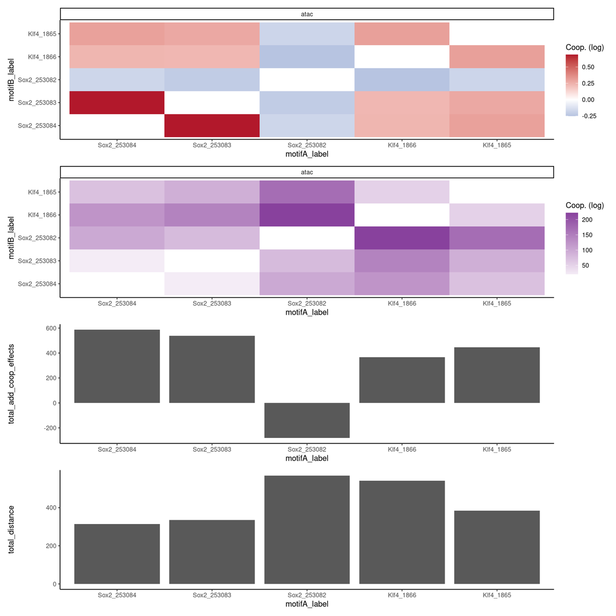

```r
paired_perturbs_labeled.df<-paired_perturbs.df %>% as.data.frame() %>% dplyr::filter(`motif.x` != 'Nanog', `motif.y` != 'Nanog') %>%
  dplyr::filter(task %in% c('atac')) %>%
  dplyr::mutate(motifA_label = paste0(motif.x, '_', motif_id.x),
                motifB_label =  paste0(motif.y, '_', motif_id.y))

#Calculate total distance
distance.df<-paired_perturbs_labeled.df %>% dplyr::group_by(motifA_label) %>% dplyr::summarize(total_distance = sum(distance))
distance.df$motifA_label<-factor(distance.df$motifA_label, levels = rev(distance.df$motifA_label))

coop.df<-paired_perturbs_labeled.df %>% dplyr::group_by(motifA_label) %>% dplyr::summarize(total_add_coop_effects = sum(add_coop_effects))
coop.df$motifA_label<-factor(coop.df$motifA_label, levels = rev(distance.df$motifA_label))

paired_perturbs_labeled.df$motifA_label<-factor(paired_perturbs_labeled.df$motifA_label, levels = rev(distance.df$motifA_label))
paired_perturbs_labeled.df$motifB_label<-factor(paired_perturbs_labeled.df$motifB_label, levels = rev(distance.df$motifA_label))

coop.plot<-(ggplot(paired_perturbs_labeled.df, aes(motifA_label, motifB_label, fill = log(add_coop)))+
  geom_tile()+
  scale_fill_gradient2(high = '#b2182b', mid = 'white', low = '#2166ac', midpoint = 0, name = 'Coop. (log)')+
  facet_grid(. ~ task)+
  theme_classic()) +
  (ggplot(paired_perturbs_labeled.df, aes(motifA_label, motifB_label, fill = distance))+
  geom_tile()+
  scale_fill_gradient2(high = '#88419d', mid = 'white', low = '#2166ac', midpoint = 0, name = 'Coop. (log)')+
  facet_grid(. ~ task)+
  theme_classic()) +
(ggplot(coop.df, aes(x = motifA_label, y = total_add_coop_effects))+
  geom_bar(stat = 'identity')+
  theme_classic())+
(ggplot(distance.df, aes(x = motifA_label, y = total_distance))+
  geom_bar(stat = 'identity')+
  theme_classic()) +
  plot_layout(ncol = 1)
coop.plot
```

```r
ggsave(paste0(figure_filepath, '/Akr1cl_candidate_cooperativity.png'), coop.plot, height = 15, width = 5)
ggsave(paste0(figure_filepath, '/Akr1cl_candidate_cooperativity.pdf'), coop.plot, height = 15, width = 5)
```

# Examine distance to perturbation plots

Plot distance from strongest pioneering motif relative to the context scores of each motif.

```r
max_distance<-300
pioneers_per_region.df<-motifs.df %>%
                     dplyr::filter(mapping_state == 'both') %>%
                     dplyr::group_by(region_id) %>%
                     dplyr::slice_max(order_by = acc_perturb, with_ties = F) %>%
                     dplyr::rename(pioneering_center = pattern_center,
                                   pioneering_contrib = acc_perturb,
                                   pioneering_motif = motif) %>%
                     dplyr::select(region_id, pioneering_center, pioneering_contrib, pioneering_motif) %>% unique()

motifs_w_centers.df<-motifs.df %>% dplyr::filter(mapping_state != 'acc') %>%
  dplyr::left_join(regions.df %>% dplyr::select(region_id, CpG_ratio)) %>%

  #Find center of most pioneering motif
  dplyr::left_join(pioneers_per_region.df) %>%

  # dplyr::filter(motif %in% c('Oct4-Sox2','Sox2', 'Klf4')) %>%
  dplyr::mutate(
    distance_from_pioneering_center_abs = abs(pattern_center - pioneering_center),
    distance_from_pioneering_center_abs_group = plyr::round_any(distance_from_pioneering_center_abs, 10, ceiling),
    distance_from_pioneering_center = pattern_center - pioneering_center,
    seq_match_group = cut(seq_match_quantile, breaks = seq(0, 1, .25), labels = paste0('q', 1:4), include.lowest = T)) %>%
  dplyr::group_by(region_id) %>%
  dplyr::mutate(centrality = sum(distance_from_pioneering_center_abs),
                pioneers_nearby = sum(mapping_state!='acc')) %>%
  dplyr::arrange(pioneering_contrib) %>%
  dplyr::ungroup() %>%
  dplyr::mutate(row = 1:nrow(.)) %>% as.data.frame()
```

Plot with the strongest pioneers depicted as gray.

```r
bind_vs_acc_genomic.plot.list<-lapply(names(motif_to_task.list), function(x){
  g<-ggplot(motifs_w_centers.df %>%
              dplyr::arrange(distance_from_pioneering_center_abs) %>%
              dplyr::filter(motif==x,
                            distance_from_pioneering_center_abs<=max_distance,
                            distance_from_pioneering_center_abs!=0),
            aes(x = bind_perturb, y = acc_perturb))+
    geom_hline(yintercept = 0, linetype = 'dotted')+
    geom_vline(xintercept = 0, linetype = 'dotted')+
    ggrastr::geom_point_rast(data = motifs_w_centers.df %>%
              dplyr::filter(motif==x,
                            distance_from_pioneering_center_abs==0) %>%
              dplyr::arrange(distance_from_pioneering_center_abs), aes(x = bind_perturb, y = acc_perturb),
              color = 'gray', size = .1, shape = 4)+
    ggrastr::geom_point_rast(aes(color = distance_from_pioneering_center_abs), size = .1)+
    ggpubr::stat_cor(method = 'spearman', label.x.npc = 'left', label.y.npc = 'top')+
    scale_color_gradientn(colours = rev(c(inferno(5, begin = .3, end = 1))),
                          name = 'Distance from strongest pioneer',
                          limits = c(0, max_distance))+
    scale_x_continuous(name = 'Binding perturb. log(WT/dA)', limits = c(-1, 4))+
    scale_y_continuous(name = 'Acc perturb. log(WT/dA)', limits = c(-1, 3))+
    ggtitle(x)+
    theme_classic() + theme(legend.position = 'bottom')
  return(g)
})
bind_vs_acc_genomic.plot<-wrap_plots(bind_vs_acc_genomic.plot.list, nrow = 1)
ggsave(paste0(figure_filepath, '/bind_perturb_vs_acc_perturb_vs_pioneering_twophase_scatter.png'), bind_vs_acc_genomic.plot, height = 4, width = 20)
ggsave(paste0(figure_filepath, '/bind_perturb_vs_acc_perturb_vs_pioneering_twophase_scatter.pdf'), bind_vs_acc_genomic.plot, height = 4, width = 20)
```

## Quantify context scores explained by PWMs and proximity

Calculate and report residuals. First do it in a combined model.

```r
residuals.df<-lapply(c('with_strongest', 'without_strongest'), function(distance_state){
  lapply(motifs_w_centers.df$motif %>% unique, function(x){
    lapply(c('acc', 'bind'), function(y){
      if(distance_state=='without_strongest'){
        df<-motifs_w_centers.df %>% dplyr::filter(distance_from_pioneering_center_abs<=max_distance, motif==x, distance_from_pioneering_center_abs!=0)
      } else {
        df<-motifs_w_centers.df %>% dplyr::filter(distance_from_pioneering_center_abs<=max_distance, motif==x)
      }

      #Find residual model
      formula.str<-as.formula(paste0(y, '_perturb ~ seq_match_quantile + distance_from_pioneering_center_abs + distance_from_peak_summit.distance + distance_from_atac_max'))
      model<-lm(formula.str, data =  df)
      af <- anova(model)
      afss <- af$"Sum Sq"
      res.df<-cbind(af,var_explained=afss/sum(afss)*100) %>%
        dplyr::mutate(motif=x, model = y, distance_state = distance_state)
      res.df$comparison<-rownames(res.df)
      res.df<-res.df %>%
        dplyr::filter(comparison != 'Residuals')
      return(res.df)
    }) %>% rbindlist()
  }) %>% rbindlist()
}) %>% rbindlist()

residuals.df
```

```
##        Df       Sum Sq      Mean Sq      F value        Pr(>F) var_explained
##     <int>        <num>        <num>        <num>         <num>         <num>
##  1:     1 4.798958e+02 4.798958e+02 2.754680e+03  0.000000e+00  8.482924e+00
##  2:     1 9.666069e+02 9.666069e+02 5.548482e+03  0.000000e+00  1.708632e+01
##  3:     1 3.561674e+01 3.561674e+01 2.044459e+02  3.554459e-46  6.295827e-01
##  4:     1 2.286745e+02 2.286745e+02 1.312629e+03 1.876819e-279  4.042187e+00
##  5:     1 5.035022e+02 5.035022e+02 3.689659e+03  0.000000e+00  1.298370e+01
##  6:     1 1.538592e+02 1.538592e+02 1.127479e+03 2.851149e-241  3.967535e+00
##  7:     1 2.871975e+01 2.871975e+01 2.104581e+02  1.782042e-47  7.405901e-01
##  8:     1 1.005759e+02 1.005759e+02 7.370195e+02 9.575922e-160  2.593530e+00
##  9:     1 6.736178e+01 6.736178e+01 1.200223e+03 1.845975e-257  3.135721e+00
## 10:     1 5.047459e+02 5.047459e+02 8.993345e+03  0.000000e+00  2.349615e+01
## 11:     1 3.688451e+00 3.688451e+00 6.571923e+01  5.413623e-16  1.716990e-01
## 12:     1 2.696988e+01 2.696988e+01 4.805376e+02 1.307826e-105  1.255460e+00
## 13:     1 1.130632e+01 1.130632e+01 3.213519e+02  1.874920e-71  1.049049e+00
```

[output cut: 151 more lines]

Run single variate regressions instead of multivariate. This may make more sense given the comparisons, so we will do both and make sure that the results don’t change the trends we observe.

```r
variables<-c('seq_match_quantile', 'distance_from_pioneering_center_abs', 'distance_from_peak_summit.distance', 'distance_from_atac_max')

residuals_indp.df<-lapply(c('with_strongest', 'without_strongest'), function(distance_state){
  lapply(motifs_w_centers.df$motif %>% unique, function(x){
    lapply(c('acc', 'bind'), function(y){
      if(distance_state=='without_strongest'){
        df<-motifs_w_centers.df %>% dplyr::filter(distance_from_pioneering_center_abs<=max_distance, motif==x, distance_from_pioneering_center_abs!=0)
      } else {
        df<-motifs_w_centers.df %>% dplyr::filter(distance_from_pioneering_center_abs<=max_distance, motif==x)
      }

      #Find residual model
      lapply(variables, function(readout){
        formula.str<-as.formula(paste0(y, '_perturb ~ ', readout))
      model<-lm(formula.str, data =  df)
      af <- anova(model)
      afss <- af$"Sum Sq"
      res.df<-cbind(af,var_explained=afss/sum(afss)*100) %>%
        dplyr::mutate(motif=x, model = y, distance_state = distance_state, comparison = readout)
      res.df$comparison<-rownames(res.df)
      res.df<-res.df %>%
        dplyr::filter(comparison != 'Residuals')
      return(res.df)
      }) %>% rbindlist()
    }) %>% rbindlist()
  }) %>% rbindlist()
}) %>% rbindlist()

residuals_indp.df
```

```
##        Df       Sum Sq      Mean Sq      F value        Pr(>F) var_explained
##     <int>        <num>        <num>        <num>         <num>         <num>
##  1:     1 4.798958e+02 4.798958e+02 2100.0357855  0.000000e+00   8.482924341
##  2:     1 1.323171e+03 1.323171e+03 6916.8412084  0.000000e+00  23.389166971
##  3:     1 2.316145e+01 2.316145e+01   93.1385311  5.375281e-22   0.409415640
##  4:     1 4.379583e+02 4.379583e+02 1901.1168713  0.000000e+00   7.741612671
##  5:     1 5.035022e+02 5.035022e+02 3380.5026643  0.000000e+00  12.983704870
##  6:     1 3.530366e+02 3.530366e+02 2269.1013905  0.000000e+00   9.103679680
##  7:     1 1.875344e+01 1.875344e+01  110.0947633  1.069968e-25   0.483590903
##  8:     1 1.623652e+02 1.623652e+02  990.0301175 9.893135e-213   4.186876666
##  9:     1 6.736178e+01 6.736178e+01  891.5012083 8.197592e-193   3.135721040
## 10:     1 5.365832e+02 5.365832e+02 9168.9921691  0.000000e+00  24.978190381
## 11:     1 1.105488e+00 1.105488e+00   14.1791295  1.665492e-04   0.051460956
## 12:     1 1.131405e+02 1.131405e+02 1531.0444135  0.000000e+00   5.266742602
## 13:     1 1.130632e+01 1.130632e+01  291.9605380  4.030633e-65   1.049049448
```

[output cut: 151 more lines]

Compare models run with independence or not (because I’m paranoid and my regression theory is very rusty)

```r
residuals.df<-dplyr::left_join(residuals.df %>% dplyr::select(motif, var_explained, comparison, model, distance_state),
                 residuals_indp.df %>% dplyr::select(motif, var_explained, comparison, model, distance_state) %>% dplyr::rename(var_explained_indp = var_explained)) %>%
  dplyr::mutate(diff_var_expl_comb_diff_indp = round(var_explained - var_explained_indp, 2)) %>%
  dplyr::arrange(desc(abs(diff_var_expl_comb_diff_indp)))
```

Yeah, they’re similar. Single variate models like distance even more than PWM scores most of the time. Glad that’s stable. Correlations also agree.

Visualize residuals

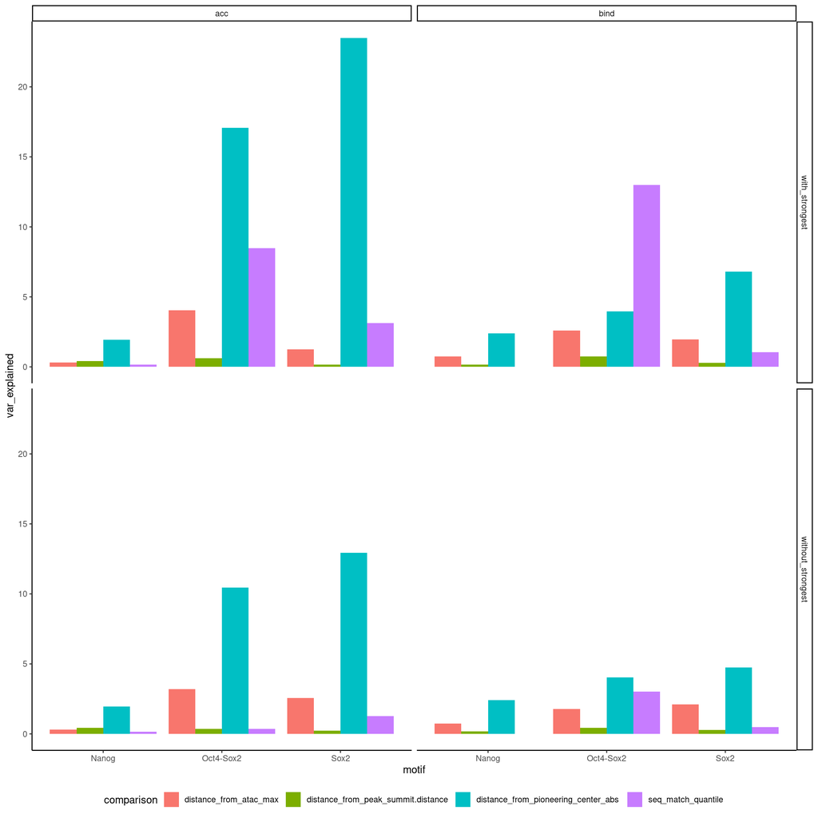

```r
plot<-residuals.df %>%
  dplyr::filter(motif %in% c('Oct4-Sox2', 'Sox2', 'Nanog')) %>%
  ggplot(., aes(x = motif, fill = comparison, y = var_explained))+
  geom_bar(stat = 'identity', position = 'dodge')+
  facet_grid(distance_state ~ model)+
  theme_classic() + theme(legend.position = 'bottom')
plot
```

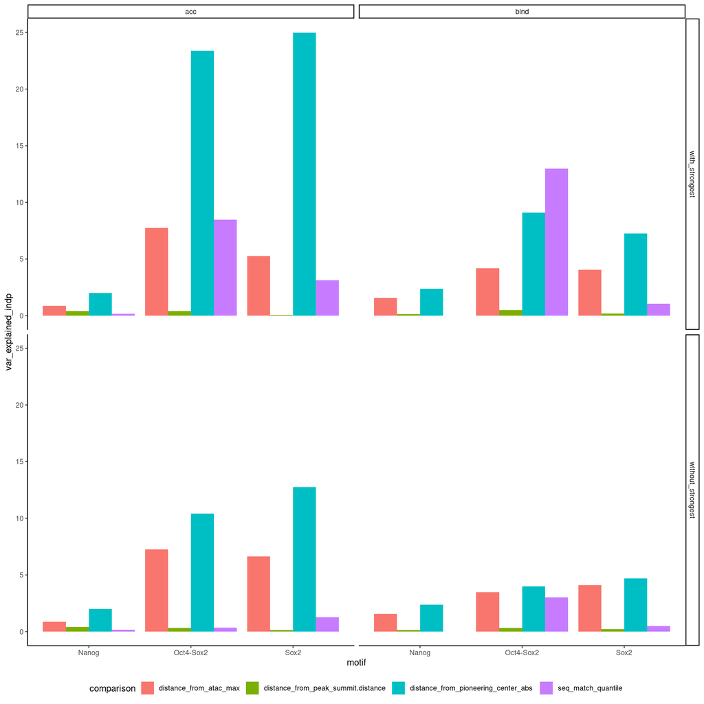

```r
ggsave(paste0(figure_filepath, '/perturb_vs_pwm_and_dist.png'), plot, height = 5, width = 6.5)
ggsave(paste0(figure_filepath, '/perturb_vs_pwm_and_dist.pdf'), plot, height = 5, width = 6.5)

#Plot independent models
plot<-residuals.df %>%
  dplyr::filter(motif %in% c('Oct4-Sox2', 'Sox2', 'Nanog')) %>%
  ggplot(., aes(x = motif, fill = comparison, y = var_explained_indp))+
  geom_bar(stat = 'identity', position = 'dodge')+
  facet_grid(distance_state ~ model)+
  theme_classic() + theme(legend.position = 'bottom')
plot
```

```r
ggsave(paste0(figure_filepath, '/perturb_vs_pwm_and_dist_independent_regression.png'), plot, height = 5, width = 6.5)
ggsave(paste0(figure_filepath, '/perturb_vs_pwm_and_dist_independent_regression.pdf'), plot, height = 5, width = 6.5)
```

Provide direct correlations between the two groups

```r
#Secondary only
motifs_w_centers.df %>% dplyr::filter(distance_from_pioneering_center_abs<=max_distance,
                                      distance_from_pioneering_center_abs!=0) %>%
              dplyr::group_by(motif) %>%
  dplyr::summarize(acc_vs_dist = cor(acc_perturb, distance_from_pioneering_center_abs, method = 'spearman'),
                   acc_vs_pwm = cor(acc_perturb, seq_match_quantile),
                   acc_vs_atac_max = cor(acc_perturb, distance_from_atac_max, method = 'spearman'),
                   acc_vs_summit = cor(acc_perturb, distance_from_peak_summit.distance, method = 'spearman'),
                   bind_vs_dist = cor(bind_perturb, distance_from_pioneering_center_abs, method = 'spearman'),
                   bind_vs_atac_max = cor(bind_perturb, distance_from_atac_max, method = 'spearman'),
                   bind_vs_summit = cor(bind_perturb, distance_from_peak_summit.distance, method = 'spearman'),
                   bind_vs_pwm = cor(bind_perturb, seq_match_quantile)) %>% as.data.frame %>%
  dplyr::filter(motif %in% c('Oct4-Sox2','Sox2', 'Nanog')) %>% as.data.frame
```

```
##       motif acc_vs_dist  acc_vs_pwm acc_vs_atac_max acc_vs_summit bind_vs_dist
## 1     Nanog  -0.1485153 -0.04054455      -0.1125788    -0.1402738   -0.1675494
## 2 Oct4-Sox2  -0.3718576  0.05968689      -0.3539685    -0.3083501   -0.2288638
## 3      Sox2  -0.3803309  0.11262841      -0.3380935    -0.2692060   -0.2319532
##   bind_vs_atac_max bind_vs_summit bind_vs_pwm
## 1       -0.1771859     -0.1127491 0.009013241
## 2       -0.2479359     -0.2258860 0.173796130
## 3       -0.2707207     -0.2176498 0.069640717
```

```r
#All motifs
motifs_w_centers.df %>% dplyr::filter(distance_from_pioneering_center_abs<=max_distance) %>%
              dplyr::group_by(motif) %>%
  dplyr::summarize(acc_vs_dist = cor(acc_perturb, distance_from_pioneering_center_abs, method = 'spearman'),
                   acc_vs_atac_max = cor(acc_perturb, distance_from_atac_max, method = 'spearman'),
                   acc_vs_summit = cor(acc_perturb, distance_from_peak_summit.distance, method = 'spearman'),
                   acc_vs_pwm = cor(acc_perturb, seq_match_quantile),
                   bind_vs_dist = cor(bind_perturb, distance_from_pioneering_center_abs, method = 'spearman'),
                   bind_vs_atac_max = cor(bind_perturb, distance_from_atac_max, method = 'spearman'),
                   bind_vs_summit = cor(bind_perturb, distance_from_peak_summit.distance, method = 'spearman'),
                   bind_vs_pwm = cor(bind_perturb, seq_match_quantile)
                   ) %>%
  dplyr::filter(motif %in% c('Oct4-Sox2','Sox2', 'Nanog')) %>% as.data.frame
```

```
##       motif acc_vs_dist acc_vs_atac_max acc_vs_summit  acc_vs_pwm bind_vs_dist
## 1     Nanog  -0.1485153      -0.1125788    -0.1402738 -0.04054455   -0.1675494
## 2 Oct4-Sox2  -0.5927859      -0.3586078    -0.3098515  0.29125460   -0.3678910
## 3      Sox2  -0.6042534      -0.3280543    -0.2350043  0.17707967   -0.2983120
##   bind_vs_atac_max bind_vs_summit bind_vs_pwm
## 1       -0.1771859     -0.1127491 0.009013241
## 2       -0.2695126     -0.2442612 0.360329084
## 3       -0.2772624     -0.2192724 0.102423115
```

### Depict for alternate models

Subselect perturbation scores for the alternate models.

```r
motifs_w_alternate_perturbs.df<-readr::read_tsv(motifs_w_alternate_perturbs.path) %>%
  dplyr::mutate(
    atac_wt_across_genome_perturb = log(`atac_wt_across_genome/atac/WT/pred_sum`) - log(`atac_wt_across_genome/atac/dA/pred_sum`),
    atac_wt_across_acc_perturb = log(`atac_wt_across_acc/atac/WT/pred_sum`) - log(`atac_wt_across_acc/atac/dA/pred_sum`),
    atac_wt_across_split_perturb = log(`atac_wt_across_split/atac/WT/pred_sum`) - log(`atac_wt_across_split/atac/dA/pred_sum`)
  )
```

```r
#Secondary only
df<-lapply(c('atac_wt_across_genome', 'atac_wt_across_acc', 'atac_wt_across_split'), function(x){
  message(x)

  motifs_w_centers.df %>% dplyr::filter(distance_from_pioneering_center_abs<=max_distance,
                                        distance_from_pioneering_center_abs!=0) %>%
    dplyr::left_join(motifs_w_alternate_perturbs.df %>% dplyr::select(motif_id, !!sym(paste0(x, '_perturb')))) %>%
    dplyr::mutate(acc_perturb = !!sym(paste0(x, '_perturb'))) %>%
    dplyr::group_by(motif) %>%

    dplyr::summarize(acc_vs_dist = cor(acc_perturb, distance_from_pioneering_center_abs, method = 'spearman'),
                     acc_vs_pwm = cor(acc_perturb, seq_match_quantile),
                     acc_vs_atac_max = cor(acc_perturb, distance_from_atac_max, method = 'spearman'),
                     acc_vs_summit = cor(acc_perturb, distance_from_peak_summit.distance, method = 'spearman')) %>% as.data.frame %>%
    dplyr::filter(motif %in% c('Oct4-Sox2','Sox2', 'Nanog')) %>% as.data.frame %>% dplyr::mutate(model = x) %>%
    dplyr::mutate(motif = factor(motif, levels = c('Oct4-Sox2','Sox2', 'Nanog'))) %>% dplyr::arrange(motif)
}) %>% rbindlist()
print(df)
```

```
##        motif acc_vs_dist  acc_vs_pwm acc_vs_atac_max acc_vs_summit
##       <fctr>       <num>       <num>           <num>         <num>
## 1: Oct4-Sox2  -0.2771096  0.18051867     -0.32202667   -0.30792142
## 2:      Sox2  -0.3508214  0.20175825     -0.35371375   -0.30072417
## 3:     Nanog  -0.0904179 -0.07449374     -0.07231007   -0.09511591
## 4: Oct4-Sox2  -0.2748046  0.12172386     -0.34232830   -0.29143063
## 5:      Sox2  -0.2572948  0.14867683     -0.30838226   -0.23265998
## 6:     Nanog  -0.1261582 -0.04685752     -0.13067098   -0.12978203
## 7: Oct4-Sox2  -0.3282180  0.13559344     -0.35840005   -0.23423614
## 8:      Sox2  -0.3216176  0.15765089     -0.32336111   -0.14380911
## 9:     Nanog  -0.1276641 -0.03129434     -0.12778794   -0.13209817
##                    model
##                   <char>
## 1: atac_wt_across_genome
## 2: atac_wt_across_genome
## 3: atac_wt_across_genome
## 4:    atac_wt_across_acc
## 5:    atac_wt_across_acc
## 6:    atac_wt_across_acc
## 7:  atac_wt_across_split
## 8:  atac_wt_across_split
## 9:  atac_wt_across_split
```

```r
readr::write_tsv(df, 'tsv/acc_vs_dist_secondary_alternate_models.tsv')

#All motifs
df<-lapply(c('atac_wt_across_genome', 'atac_wt_across_acc', 'atac_wt_across_split'), function(x){
  message(x)
  motifs_w_centers.df %>% dplyr::filter(distance_from_pioneering_center_abs<=max_distance) %>%
    dplyr::left_join(motifs_w_alternate_perturbs.df %>% dplyr::select(motif_id, !!sym(paste0(x, '_perturb')))) %>%
    dplyr::mutate(acc_perturb = !!sym(paste0(x, '_perturb'))) %>%
    dplyr::group_by(motif) %>%

    dplyr::summarize(acc_vs_dist = cor(acc_perturb, distance_from_pioneering_center_abs, method = 'spearman'),
                     acc_vs_pwm = cor(acc_perturb, seq_match_quantile),
                     acc_vs_atac_max = cor(acc_perturb, distance_from_atac_max, method = 'spearman'),
                     acc_vs_summit = cor(acc_perturb, distance_from_peak_summit.distance, method = 'spearman')) %>% as.data.frame %>%
    dplyr::filter(motif %in% c('Oct4-Sox2','Sox2', 'Nanog')) %>% as.data.frame %>% dplyr::mutate(model = x) %>%
    dplyr::mutate(motif = factor(motif, levels = c('Oct4-Sox2','Sox2', 'Nanog'))) %>% dplyr::arrange(motif)
}) %>% rbindlist()
print(df)
```

```
##        motif acc_vs_dist  acc_vs_pwm acc_vs_atac_max acc_vs_summit
##       <fctr>       <num>       <num>           <num>         <num>
## 1: Oct4-Sox2  -0.4118870  0.31870145     -0.34765007   -0.34528557
## 2:      Sox2  -0.3730412  0.20764134     -0.34913971   -0.30211275
## 3:     Nanog  -0.0904179 -0.07449374     -0.07231007   -0.09511591
## 4: Oct4-Sox2  -0.3947880  0.25916512     -0.35436513   -0.32190835
## 5:      Sox2  -0.3872225  0.17848793     -0.31466722   -0.22837598
## 6:     Nanog  -0.1261582 -0.04685752     -0.13067098   -0.12978203
## 7: Oct4-Sox2  -0.4982279  0.34976705     -0.38900284   -0.25919320
## 8:      Sox2  -0.4456844  0.19039973     -0.33284291   -0.14582645
## 9:     Nanog  -0.1276641 -0.03129434     -0.12778794   -0.13209817
##                    model
##                   <char>
## 1: atac_wt_across_genome
## 2: atac_wt_across_genome
## 3: atac_wt_across_genome
## 4:    atac_wt_across_acc
## 5:    atac_wt_across_acc
## 6:    atac_wt_across_acc
## 7:  atac_wt_across_split
## 8:  atac_wt_across_split
## 9:  atac_wt_across_split
```

```r
readr::write_tsv(df, 'tsv/acc_vs_dist_all_alternate_models.tsv')
```

## Show Sox2 correlations at specific sequences

Find Sox2 specific-sequences correlations on these plots.

```r
motifs_w_centers.df %>% dplyr::filter(region_id==curated_region_id)
```

```
##    seqnames    start      end width strand chrom              name score
## 1      chr1 65037654 65037663    10      -  chr1  Sox2_253082_3491     0
## 2      chr1 65037732 65037741    10      -  chr1  Sox2_253083_3491     0
## 3      chr1 65037753 65037762    10      -  chr1  Sox2_253084_3491     0
## 4      chr1 65037823 65037834    12      +  chr1    Klf4_1865_3491     0
## 5      chr1 65037875 65037886    12      -  chr1    Klf4_1866_3491     0
## 6      chr1 65038094 65038105    12      +  chr1  Zic3_161005_3491     0
## 7      chr1 65037509 65037517     9      +  chr1 Nanog_313091_3491     0
## 8      chr1 65037556 65037564     9      -  chr1 Nanog_313092_3491     0
## 9      chr1 65037941 65037949     9      -  chr1 Nanog_313093_3491     0
## 10     chr1 65037952 65037960     9      -  chr1 Nanog_313094_3491     0
##    motif_length motif motif_id region_id region_start region_end
## 1             9  Sox2   253082      3491     65036790   65038822
## 2             9  Sox2   253083      3491     65036790   65038822
## 3             9  Sox2   253084      3491     65036790   65038822
```

[output cut: 403 more lines]

```r
motifs_w_centers.df %>%
  dplyr::filter(motif=='Sox2',
                seq %in% c(motifs_w_centers.df %>% dplyr::filter(region_id==curated_region_id, motif=='Sox2') %>% .$seq),
                distance_from_pioneering_center_abs<=max_distance) %>%
  .$seq %>%
  table()
```

```
## .
## GACAAAGAC GACAAAGGG
##       115       451
```

```r
bind_vs_acc_genomic_vs_dist.plot<-ggplot(motifs_w_centers.df %>%
                                          dplyr::filter(motif=='Sox2',
                                                        seq %in% c(motifs_w_centers.df %>% dplyr::filter(region_id==curated_region_id, motif=='Sox2') %>% .$seq),
                                                        distance_from_pioneering_center_abs<=max_distance,
                                                        distance_from_pioneering_center_abs!=0) %>%
                                          dplyr::arrange(distance_from_pioneering_center_abs),
                                        aes(x = bind_perturb, y = acc_perturb))+
  geom_hline(yintercept = 0, linetype = 'dotted')+
  geom_vline(xintercept = 0, linetype = 'dotted')+
  ggrastr::geom_point_rast(data = motifs_w_centers.df %>%
                             dplyr::filter(motif=='Sox2',
                                           seq %in% c(motifs_w_centers.df %>%
                                                        dplyr::filter(region_id==curated_region_id, motif=='Sox2') %>% .$seq)) %>%
                             dplyr::filter(distance_from_pioneering_center_abs==0) %>%
                             dplyr::arrange(distance_from_pioneering_center_abs), aes(x = bind_perturb, y = acc_perturb),
                           color = 'gray', size = 1.5, shape = 4)+
  ggrastr::geom_point_rast(aes(color = distance_from_pioneering_center_abs), size = 1)+
  geom_point(data = motifs_w_centers.df %>% dplyr::filter(region_id==curated_region_id, motif=='Sox2'), color = 'black')+
  ggpubr::stat_cor(method = 'spearman', label.x.npc = 'left', label.y.npc = 'top')+
  scale_color_gradientn(colours = rev(c(turbo(5, begin = 0.05, end = .95))),
                        name = 'Distance from strongest pioneer',
                        limits = c(0, max_distance))+
  scale_x_continuous(name = 'Binding perturb. log(WT/dA)', limits = c(-.2, 1.25))+
  scale_y_continuous(name = 'Acc perturb. log(WT/dA)', limits = c(-.2, 1.25))+
  facet_grid(. ~ seq)+
  ggtitle('Sox2')+
  theme_classic() + theme(legend.position = 'bottom')

ggsave(paste0(figure_filepath, '/bind_perturb_vs_acc_perturb_vs_pioneering_center_scatter_sox2.png'), bind_vs_acc_genomic_vs_dist.plot, height = 4, width = 6.5)
ggsave(paste0(figure_filepath, '/bind_perturb_vs_acc_perturb_vs_pioneering_center_scatter_sox2.pdf'), bind_vs_acc_genomic_vs_dist.plot, height = 4, width = 6.5)
```

Calculate and report correlation values

```r
#Secondary only
motifs_w_centers.df %>% dplyr::filter(distance_from_pioneering_center_abs<=max_distance,
                                      distance_from_pioneering_center_abs!=0,
                                      motif=='Sox2',
                                      seq %in% c(motifs_w_centers.df %>% dplyr::filter(region_id==curated_region_id, motif=='Sox2') %>% .$seq)) %>%
  dplyr::group_by(motif, seq) %>%
  dplyr::summarize(acc_vs_dist = cor(acc_perturb, distance_from_pioneering_center_abs, method = 'spearman'),
                   acc_vs_atac_max = cor(acc_perturb, distance_from_atac_max, method = 'spearman'),
                   acc_vs_summit = cor(acc_perturb, distance_from_peak_summit.distance, method = 'spearman'),
                   bind_vs_dist = cor(bind_perturb, distance_from_pioneering_center_abs, method = 'spearman'),
                   bind_vs_atac_max = cor(bind_perturb, distance_from_atac_max, method = 'spearman'),
                   bind_vs_summit = cor(bind_perturb, distance_from_peak_summit.distance, method = 'spearman')) %>%
  as.data.frame
```

```
##   motif       seq acc_vs_dist acc_vs_atac_max acc_vs_summit bind_vs_dist
## 1  Sox2 GACAAAGAC  -0.3796080      -0.3928746    -0.2949084   -0.2451523
## 2  Sox2 GACAAAGGG  -0.4656125      -0.4646513    -0.2214561   -0.3537827
##   bind_vs_atac_max bind_vs_summit
## 1       -0.4312172     -0.2451154
## 2       -0.3783362     -0.2822924
```

```r
#All motifs
motifs_w_centers.df %>% dplyr::filter(distance_from_pioneering_center_abs<=max_distance,
                                      motif=='Sox2',
                                      seq %in% c(motifs_w_centers.df %>% dplyr::filter(region_id==curated_region_id, motif=='Sox2') %>% .$seq)) %>%
  dplyr::group_by(motif, seq) %>%
  dplyr::summarize(acc_vs_dist = cor(acc_perturb, distance_from_pioneering_center_abs, method = 'spearman'),
                   acc_vs_atac_max = cor(acc_perturb, distance_from_atac_max, method = 'spearman'),
                   acc_vs_summit = cor(acc_perturb, distance_from_peak_summit.distance, method = 'spearman'),
                   acc_vs_pwm = cor(acc_perturb, seq_match_quantile),
                   bind_vs_dist = cor(bind_perturb, distance_from_pioneering_center_abs, method = 'spearman'),
                   bind_vs_atac_max = cor(bind_perturb, distance_from_atac_max, method = 'spearman'),
                   bind_vs_summit = cor(bind_perturb, distance_from_peak_summit.distance, method = 'spearman'),
                   bind_vs_pwm = cor(bind_perturb, seq_match_quantile)
  ) %>% as.data.frame
```

```
##   motif       seq acc_vs_dist acc_vs_atac_max acc_vs_summit acc_vs_pwm
## 1  Sox2 GACAAAGAC  -0.5578998      -0.4142738    -0.2634943         NA
## 2  Sox2 GACAAAGGG  -0.6248865      -0.3921722    -0.1741474         NA
##   bind_vs_dist bind_vs_atac_max bind_vs_summit bind_vs_pwm
## 1   -0.3064083       -0.4308968     -0.2297467          NA
## 2   -0.2868424       -0.2968257     -0.2477503          NA
```

### Depict for alternate models

```r
#Secondary only
df<-lapply(c('atac_wt_across_genome', 'atac_wt_across_acc', 'atac_wt_across_split'), function(x){
  message(x)

  motifs_w_centers.df %>% dplyr::filter(distance_from_pioneering_center_abs<=max_distance,
                                        distance_from_pioneering_center_abs!=0, motif=='Sox2',
                                      seq %in% c(motifs_w_centers.df %>% dplyr::filter(region_id==curated_region_id, motif=='Sox2') %>% .$seq)) %>%
    dplyr::left_join(motifs_w_alternate_perturbs.df %>% dplyr::select(motif_id, !!sym(paste0(x, '_perturb')))) %>%
    dplyr::mutate(acc_perturb = !!sym(paste0(x, '_perturb'))) %>%
    dplyr::group_by(motif, seq) %>%

    dplyr::summarize(acc_vs_dist = cor(acc_perturb, distance_from_pioneering_center_abs, method = 'spearman'),
                     acc_vs_pwm = cor(acc_perturb, seq_match_quantile),
                     acc_vs_atac_max = cor(acc_perturb, distance_from_atac_max, method = 'spearman'),
                     acc_vs_summit = cor(acc_perturb, distance_from_peak_summit.distance, method = 'spearman'), model = x) %>% as.data.frame%>% dplyr::arrange(desc(seq))
}) %>% rbindlist()
print(df)
```

```
##     motif       seq acc_vs_dist acc_vs_pwm acc_vs_atac_max acc_vs_summit
##    <char>    <char>       <num>      <num>           <num>         <num>
## 1:   Sox2 GACAAAGGG  -0.4848638         NA      -0.4265460    -0.3296396
## 2:   Sox2 GACAAAGAC  -0.3507735         NA      -0.3344089    -0.3703608
## 3:   Sox2 GACAAAGGG  -0.4579075         NA      -0.4879295    -0.3193028
## 4:   Sox2 GACAAAGAC  -0.2843612         NA      -0.2812837    -0.1650084
## 5:   Sox2 GACAAAGGG  -0.4593968         NA      -0.5004897    -0.1592041
## 6:   Sox2 GACAAAGAC  -0.4094995         NA      -0.3165675    -0.2184270
##                    model
##                   <char>
## 1: atac_wt_across_genome
## 2: atac_wt_across_genome
## 3:    atac_wt_across_acc
## 4:    atac_wt_across_acc
## 5:  atac_wt_across_split
## 6:  atac_wt_across_split
```

```r
readr::write_tsv(df, 'tsv/acc_vs_dist_secondary_akr1cl_alternate_models.tsv')

#All motifs
df<-lapply(c('atac_wt_across_genome', 'atac_wt_across_acc', 'atac_wt_across_split'), function(x){
  message(x)
  motifs_w_centers.df %>% dplyr::filter(distance_from_pioneering_center_abs<=max_distance,
                                        motif=='Sox2',
                                        seq %in% c(motifs_w_centers.df %>% dplyr::filter(region_id==curated_region_id, motif=='Sox2') %>% .$seq)) %>%
    dplyr::left_join(motifs_w_alternate_perturbs.df %>% dplyr::select(motif_id, !!sym(paste0(x, '_perturb')))) %>%
    dplyr::mutate(acc_perturb = !!sym(paste0(x, '_perturb'))) %>%
    dplyr::group_by(motif, seq) %>%

    dplyr::summarize(acc_vs_dist = cor(acc_perturb, distance_from_pioneering_center_abs, method = 'spearman'),
                     acc_vs_pwm = cor(acc_perturb, seq_match_quantile),
                     acc_vs_atac_max = cor(acc_perturb, distance_from_atac_max, method = 'spearman'),
                     acc_vs_summit = cor(acc_perturb, distance_from_peak_summit.distance, method = 'spearman'), model = x) %>% as.data.frame %>% dplyr::arrange(desc(seq))
}) %>% rbindlist()
print(df)
```

```
##     motif       seq acc_vs_dist acc_vs_pwm acc_vs_atac_max acc_vs_summit
##    <char>    <char>       <num>      <num>           <num>         <num>
## 1:   Sox2 GACAAAGGG  -0.3905980         NA      -0.4107741    -0.2737749
## 2:   Sox2 GACAAAGAC  -0.3532544         NA      -0.3348202    -0.3092724
## 3:   Sox2 GACAAAGGG  -0.4313334         NA      -0.4600414    -0.3078994
## 4:   Sox2 GACAAAGAC  -0.3244726         NA      -0.3205764    -0.2233823
## 5:   Sox2 GACAAAGGG  -0.4502063         NA      -0.4410537    -0.1297678
## 6:   Sox2 GACAAAGAC  -0.5304315         NA      -0.3893531    -0.2659407
##                    model
##                   <char>
## 1: atac_wt_across_genome
## 2: atac_wt_across_genome
## 3:    atac_wt_across_acc
## 4:    atac_wt_across_acc
## 5:  atac_wt_across_split
## 6:  atac_wt_across_split
```

```r
readr::write_tsv(df, 'tsv/acc_vs_dist_all_akr1cl_alternate_models.tsv')
```